# Data Analysis of the “War of the Five Kings” - Game of Thrones

## Introduction

The War of the Five Kings is a famous civil war described in the well-known serious fantasy novel “Game of Thrones”. This is a civil strife with an unprecedented scale that involves seven kingdoms. As the name implies, a total of five persons claim to be the king during the war: Joffrey Baratheon, Stannis Baratheon and Renly Baratheon all claim to be the rightful heir of the iron throne. Moreover, Robb Stark is elected by the barons of the northern border to the King in the North, and Balon Greyjoy erects the flag of independence again and claims to be the King of the Iron Islands, in an attempt to shake off the ruling of the Iron Throne.

This dataset (battles.csv) contains all the battles during the War of the Five Kings. It is part of the [Game of Thrones](https://www.kaggle.com/mylesoneill/game-of-thrones) in Kaggle.

Variables in the dataset and meanings:

- **name:** String variable. The name of the battle.
- **year:** Numeric variable. The year of the battle.
- **battle_number:** Numeric variable. A unique ID number for the battle.
- **attacker_king:** Categorical. The attacker's king. A slash indicators that the king charges over the course of the war. For example, "Joffrey/Tommen Baratheon" is coded as such because one king follows the other in the Iron Throne.
- **defender_king:** Categorical variable. The defender's king.
- **attacker_1:** String variable. Major house attacking.
- **attacker_2:** String variable. Major house attacking.
- **attacker_3:** String variable. Major house attacking.
- **attacker_4:** String variable. Major house attacking.
- **defender_1:** String variable. Major house defending.
- **defender_2:** String variable. Major house defending.
- **defender_3:** String variable. Major house defending.
- **defender_4:** String variable. Major house defending.
- **attacker_outcome:** Categorical variable. The outcome from the perspective of the attacker. Categories: win, loss, draw.
- **battle_type:** Categorical variable. A classification of the battle's primary type. Categories:
  - pitched_battle: Armies meet in a location and fight. This is also the baseline category.
  - ambush: A battle where stealth or subterfuge was the primary means of attack.
  - siege: A prolonged of a fortied position.
  - razing: An attack against an undefended position
- **major_death:** Binary variable. If there was a death of a major figure during the battle.
- **major_capture:** Binary variable. If there was the capture of the major figure during the battle.
- **attacker_size:** Numeric variable. The size of the attacker's force. No distinction is made between the types of soldiers such as cavalry and footmen.
- **defender_size:** Numeric variable. The size of the defenders's force. No distinction is made between the types of soldiers such as cavalry and footmen.
- **attacker_commander:** String variable. Major commanders of the attackers. Commander's names are included without honoric titles and commandders are seperated by commas.
- **defender_commander:** String variable. Major commanders of the defener. Commander's names are included without honoric titles and commandders are seperated by commas.
- **summer:** Binary variable. Was it summer?
- **location:** String variable. The location of the battle.
- **region:** Categorical variable. The region where the battle takes place. Categories: Beyond the Wall, The North, The Iron Islands, The Riverlands, The Vale of Arryn, The Westerlands, The Crownlands, The Reach, The Stormlands, Dorne
- **note:** String variable. Coding notes regarding individual observations..

## Project Instructions

We have provided the data analysis flow for this project, but you will have to complete the codes by yourself. Your failure to complete this project means you are temporarily incapable to achieve the nanodegree of data analysis (advanced). We suggest you achieve a nanodegree of data analysis (introductory) and master the knowledge required to proceed with the advanced course.

Records in the process of data analysis are also an important part of the data analysis report. You can insert markdown cells where you need to record your key steps and reasoning processes during the data analysis. For example, what characteristics do data have? What do statistical data mean? What conclusion can you derive from visualization? What’s your analysis next step? Why do you perform the analysis? If you fail to do this, you can’t pass this project.

> **Tip**: Quoted sections like this will provide helpful instructions on how to navigate and use an iPython notebook.

## Ask questions

Under this project, you will perform an explorative analysis of data as a data analyst. You will understand the basic flow of data analysis. Before starting data analysis, please think several questions about these battles you will have to understand. For example, what region sees the largest number of battles? What king wins the most victories? What key factors influence the outcome of a battle?

## **Question**： What king wins the most victories?

**Answer**：Based on different roles in offensive and defensive, I can get different results. As attacker, it is clear that 'Joffrey/Tommen Baratheon' wins the most victories, and as defender, 'Joffrey/Tommen Baratheon' also get the most win than other kings. So, after combing all data, we can get that 'Joffrey/Tommen Baratheon' wins the most victories in total.

After setting questions, we will start importing data and perform an explorative analysis to answer the questions set above.

> **Tip**: If you double click on this cell, you will see the text change so that all of the formatting is removed. This allows you to edit this block of text. This block of text is written using [Markdown](http://daringfireball.net/projects/markdown/syntax), which is a way to format text using headers, links, italics, and many other options. You will learn more about Markdown later in the Nanodegree Program. Hit **Shift** + **Enter** or **Shift** + **Return**.

## Data Wrangling

> **Tip**: You can run a code cell like you formatted Markdown cells by clicking on the cell and using the keyboard shortcut **Shift** + **Enter** or **Shift** + **Return**. Alternatively, a code cell can be executed using the **Play** button in the toolbar after selecting it. While the cell is running, you will see an asterisk in the message to the left of the cell, i.e. `In [*]:`. The asterisk will change into a number to show that execution has completed, e.g. `In [1]`. If there is output, it will show up as `Out [1]:`, with an appropriate number to match the "In" number.

```python
# TO DO: load pacakges
import pandas as pd
import numpy as np
import matplotlib.pyplot as plt
%matplotlib inline
```

```python
# TO DO: load the dataset
df=pd.read_csv('battles.csv')
df.head()
```

|  | name | year | battle_number | attacker_king | defender_king | attacker_1 | attacker_2 | attacker_3 | attacker_4 | defender_1 | ... | major_death | major_capture | attacker_size | defender_size | attacker_commander | defender_commander | summer | location | region | note |
| --- | --- | --- | --- | --- | --- | --- | --- | --- | --- | --- | --- | --- | --- | --- | --- | --- | --- | --- | --- | --- | --- |
| 0 | Battle of the Golden Tooth | 298 | 1 | Joffrey/Tommen Baratheon | Robb Stark | Lannister | NaN | NaN | NaN | Tully | ... | 1.0 | 0.0 | 15000.0 | 4000.0 | Jaime Lannister | Clement Piper, Vance | 1.0 | Golden Tooth | The Westerlands | NaN |
| 1 | Battle at the Mummer's Ford | 298 | 2 | Joffrey/Tommen Baratheon | Robb Stark | Lannister | NaN | NaN | NaN | Baratheon | ... | 1.0 | 0.0 | NaN | 120.0 | Gregor Clegane | Beric Dondarrion | 1.0 | Mummer's Ford | The Riverlands | NaN |
| 2 | Battle of Riverrun | 298 | 3 | Joffrey/Tommen Baratheon | Robb Stark | Lannister | NaN | NaN | NaN | Tully | ... | 0.0 | 1.0 | 15000.0 | 10000.0 | Jaime Lannister, Andros Brax | Edmure Tully, Tytos Blackwood | 1.0 | Riverrun | The Riverlands | NaN |
| 3 | Battle of the Green Fork | 298 | 4 | Robb Stark | Joffrey/Tommen Baratheon | Stark | NaN | NaN | NaN | Lannister | ... | 1.0 | 1.0 | 18000.0 | 20000.0 | Roose Bolton, Wylis Manderly, Medger Cerwyn, H... | Tywin Lannister, Gregor Clegane, Kevan Lannist... | 1.0 | Green Fork | The Riverlands | NaN |
| 4 | Battle of the Whispering Wood | 298 | 5 | Robb Stark | Joffrey/Tommen Baratheon | Stark | Tully | NaN | NaN | Lannister | ... | 1.0 | 1.0 | 1875.0 | 6000.0 | Robb Stark, Brynden Tully | Jaime Lannister | 1.0 | Whispering Wood | The Riverlands | NaN |

5 rows × 25 columns

```python
# TO DO: check the dataset general info
df.info()
```

```
<class 'pandas.core.frame.DataFrame'>
RangeIndex: 38 entries, 0 to 37
Data columns (total 25 columns):
name                  38 non-null object
year                  38 non-null int64
battle_number         38 non-null int64
attacker_king         36 non-null object
defender_king         35 non-null object
attacker_1            38 non-null object
attacker_2            10 non-null object
attacker_3            3 non-null object
attacker_4            2 non-null object
defender_1            37 non-null object
defender_2            2 non-null object
defender_3            0 non-null float64
defender_4            0 non-null float64
attacker_outcome      37 non-null object
battle_type           37 non-null object
major_death           37 non-null float64
major_capture         37 non-null float64
attacker_size         24 non-null float64
defender_size         19 non-null float64
attacker_commander    37 non-null object
defender_commander    28 non-null object
summer                37 non-null float64
location              37 non-null object
region                38 non-null object
note                  5 non-null object
dtypes: float64(7), int64(2), object(16)
memory usage: 7.5+ KB
```

```python
# check the number of unique value in each column
df.nunique()
```

```
name                  38
year                   3
battle_number         38
attacker_king          4
defender_king          6
attacker_1            11
attacker_2             7
attacker_3             2
attacker_4             1
defender_1            12
defender_2             2
defender_3             0
defender_4             0
attacker_outcome       2
battle_type            4
major_death            2
major_capture          2
attacker_size         19
defender_size         14
attacker_commander    31
defender_commander    28
summer                 2
location              27
region                 7
note                   5
dtype: int64
```

From the data above, I can get that there are 4 unique kings as attacker, and 6 kings as defender.

```python
# check the name of 4 attacker kings
df['attacker_king'].unique()
```

```
array(['Joffrey/Tommen Baratheon', 'Robb Stark', 'Balon/Euron Greyjoy',
       'Stannis Baratheon', nan], dtype=object)
```

```python
# check the name of 6 defender kings
df['defender_king'].unique()
```

```
array(['Robb Stark', 'Joffrey/Tommen Baratheon', 'Balon/Euron Greyjoy',
       'Renly Baratheon', nan, 'Mance Rayder', 'Stannis Baratheon'], dtype=object)
```

And both in the lists of attacker kings and defender kings, there are some NaN value, so I need to clean the data.

```python
# TO DO: clean the data (optional: only there are problems)
# check which rows include NaN value in the 'attacker_king' column
df[df['attacker_king'].isnull().values==True]
```

|  | name | year | battle_number | attacker_king | defender_king | attacker_1 | attacker_2 | attacker_3 | attacker_4 | defender_1 | ... | major_death | major_capture | attacker_size | defender_size | attacker_commander | defender_commander | summer | location | region | note |
| --- | --- | --- | --- | --- | --- | --- | --- | --- | --- | --- | --- | --- | --- | --- | --- | --- | --- | --- | --- | --- | --- |
| 22 | Battle of the Burning Septry | 299 | 23 | NaN | NaN | Brotherhood without Banners | NaN | NaN | NaN | Brave Companions | ... | 0.0 | 0.0 | NaN | NaN | NaN | NaN | 1.0 | NaN | The Riverlands | NaN |
| 29 | Sack of Saltpans | 300 | 30 | NaN | NaN | Brave Companions | NaN | NaN | NaN | NaN | ... | 0.0 | 0.0 | NaN | NaN | Rorge | NaN | 0.0 | Saltpans | The Riverlands | NaN |

2 rows × 25 columns

```python
# check which rows include NaN value in the 'defender_king' column
df[df['defender_king'].isnull().values==True]
```

|  | name | year | battle_number | attacker_king | defender_king | attacker_1 | attacker_2 | attacker_3 | attacker_4 | defender_1 | ... | major_death | major_capture | attacker_size | defender_size | attacker_commander | defender_commander | summer | location | region | note |
| --- | --- | --- | --- | --- | --- | --- | --- | --- | --- | --- | --- | --- | --- | --- | --- | --- | --- | --- | --- | --- | --- |
| 22 | Battle of the Burning Septry | 299 | 23 | NaN | NaN | Brotherhood without Banners | NaN | NaN | NaN | Brave Companions | ... | 0.0 | 0.0 | NaN | NaN | NaN | NaN | 1.0 | NaN | The Riverlands | NaN |
| 24 | Retaking of Harrenhal | 299 | 25 | Joffrey/Tommen Baratheon | NaN | Lannister | NaN | NaN | NaN | Brave Companions | ... | 1.0 | 0.0 | NaN | NaN | Gregor Clegane | Vargo Hoat | 1.0 | Harrenhal | The Riverlands | NaN |
| 29 | Sack of Saltpans | 300 | 30 | NaN | NaN | Brave Companions | NaN | NaN | NaN | NaN | ... | 0.0 | 0.0 | NaN | NaN | Rorge | NaN | 0.0 | Saltpans | The Riverlands | NaN |

3 rows × 25 columns

As the data shows above, there are three rows which include NaN values, and it is clear that we can drop the 22nd and 29th row because these two rows have no data in both 'attacker_king' and 'defender_king' columns; however, we need to check the result of the fight about the 24th row which include the information about a specific attacker king.

```python
# check the outcome of the 24th row
df['attacker_outcome'][24]
```

```
'win'
```

From the outcome data, I can know that the 24th data is valuable for my question, so I cannot drop this row.

```python
# use 'battle_number','attacker_king','defender_king','attacker_outcome'to analyze
df_1 = df[['battle_number','attacker_king','defender_king','attacker_outcome']]
df_1
```

|  | battle_number | attacker_king | defender_king | attacker_outcome |
| --- | --- | --- | --- | --- |
| 0 | 1 | Joffrey/Tommen Baratheon | Robb Stark | win |
| 1 | 2 | Joffrey/Tommen Baratheon | Robb Stark | win |
| 2 | 3 | Joffrey/Tommen Baratheon | Robb Stark | win |
| 3 | 4 | Robb Stark | Joffrey/Tommen Baratheon | loss |
| 4 | 5 | Robb Stark | Joffrey/Tommen Baratheon | win |
| 5 | 6 | Robb Stark | Joffrey/Tommen Baratheon | win |
| 6 | 7 | Joffrey/Tommen Baratheon | Robb Stark | win |
| 7 | 8 | Balon/Euron Greyjoy | Robb Stark | win |
| 8 | 9 | Balon/Euron Greyjoy | Robb Stark | win |
| 9 | 10 | Balon/Euron Greyjoy | Robb Stark | win |
| 10 | 11 | Robb Stark | Balon/Euron Greyjoy | win |
| 11 | 12 | Balon/Euron Greyjoy | Robb Stark | win |
| 12 | 13 | Balon/Euron Greyjoy | Balon/Euron Greyjoy | win |
| 13 | 14 | Joffrey/Tommen Baratheon | Robb Stark | win |
| 14 | 15 | Robb Stark | Joffrey/Tommen Baratheon | win |
| 15 | 16 | Stannis Baratheon | Renly Baratheon | win |
| 16 | 17 | Joffrey/Tommen Baratheon | Robb Stark | loss |
| 17 | 18 | Robb Stark | Joffrey/Tommen Baratheon | win |
| 18 | 19 | Robb Stark | Joffrey/Tommen Baratheon | win |
| 19 | 20 | Stannis Baratheon | Joffrey/Tommen Baratheon | loss |
| 20 | 21 | Robb Stark | Joffrey/Tommen Baratheon | win |
| 21 | 22 | Robb Stark | Joffrey/Tommen Baratheon | loss |
| 22 | 23 | NaN | NaN | win |
| 23 | 24 | Joffrey/Tommen Baratheon | Robb Stark | win |
| 24 | 25 | Joffrey/Tommen Baratheon | NaN | win |
| 25 | 26 | Joffrey/Tommen Baratheon | Robb Stark | win |
| 26 | 27 | Robb Stark | Joffrey/Tommen Baratheon | win |
| 27 | 28 | Stannis Baratheon | Mance Rayder | loss |
| 28 | 29 | Joffrey/Tommen Baratheon | Balon/Euron Greyjoy | win |
| 29 | 30 | NaN | NaN | win |
| 30 | 31 | Stannis Baratheon | Balon/Euron Greyjoy | win |
| 31 | 32 | Balon/Euron Greyjoy | Joffrey/Tommen Baratheon | win |
| 32 | 33 | Balon/Euron Greyjoy | Joffrey/Tommen Baratheon | win |
| 33 | 34 | Joffrey/Tommen Baratheon | Stannis Baratheon | win |
| 34 | 35 | Joffrey/Tommen Baratheon | Stannis Baratheon | win |
| 35 | 36 | Joffrey/Tommen Baratheon | Robb Stark | win |
| 36 | 37 | Joffrey/Tommen Baratheon | Robb Stark | win |
| 37 | 38 | Stannis Baratheon | Joffrey/Tommen Baratheon | NaN |

From the above data, I notice that the 37th row doesn't include attacker outcome, so I also need to drop it.

```python
# drop the 22nd and 29th rows
df_1 = df_1.dropna(subset=['attacker_king'])
```

```python
# drop the 37th row
df_1 = df_1.dropna(subset=['attacker_outcome'])
df_1
```

|  | battle_number | attacker_king | defender_king | attacker_outcome |
| --- | --- | --- | --- | --- |
| 0 | 1 | Joffrey/Tommen Baratheon | Robb Stark | win |
| 1 | 2 | Joffrey/Tommen Baratheon | Robb Stark | win |
| 2 | 3 | Joffrey/Tommen Baratheon | Robb Stark | win |
| 3 | 4 | Robb Stark | Joffrey/Tommen Baratheon | loss |
| 4 | 5 | Robb Stark | Joffrey/Tommen Baratheon | win |
| 5 | 6 | Robb Stark | Joffrey/Tommen Baratheon | win |
| 6 | 7 | Joffrey/Tommen Baratheon | Robb Stark | win |
| 7 | 8 | Balon/Euron Greyjoy | Robb Stark | win |
| 8 | 9 | Balon/Euron Greyjoy | Robb Stark | win |
| 9 | 10 | Balon/Euron Greyjoy | Robb Stark | win |
| 10 | 11 | Robb Stark | Balon/Euron Greyjoy | win |
| 11 | 12 | Balon/Euron Greyjoy | Robb Stark | win |
| 12 | 13 | Balon/Euron Greyjoy | Balon/Euron Greyjoy | win |
| 13 | 14 | Joffrey/Tommen Baratheon | Robb Stark | win |
| 14 | 15 | Robb Stark | Joffrey/Tommen Baratheon | win |
| 15 | 16 | Stannis Baratheon | Renly Baratheon | win |
| 16 | 17 | Joffrey/Tommen Baratheon | Robb Stark | loss |
| 17 | 18 | Robb Stark | Joffrey/Tommen Baratheon | win |
| 18 | 19 | Robb Stark | Joffrey/Tommen Baratheon | win |
| 19 | 20 | Stannis Baratheon | Joffrey/Tommen Baratheon | loss |
| 20 | 21 | Robb Stark | Joffrey/Tommen Baratheon | win |
| 21 | 22 | Robb Stark | Joffrey/Tommen Baratheon | loss |
| 23 | 24 | Joffrey/Tommen Baratheon | Robb Stark | win |
| 24 | 25 | Joffrey/Tommen Baratheon | NaN | win |
| 25 | 26 | Joffrey/Tommen Baratheon | Robb Stark | win |
| 26 | 27 | Robb Stark | Joffrey/Tommen Baratheon | win |
| 27 | 28 | Stannis Baratheon | Mance Rayder | loss |
| 28 | 29 | Joffrey/Tommen Baratheon | Balon/Euron Greyjoy | win |
| 30 | 31 | Stannis Baratheon | Balon/Euron Greyjoy | win |
| 31 | 32 | Balon/Euron Greyjoy | Joffrey/Tommen Baratheon | win |
| 32 | 33 | Balon/Euron Greyjoy | Joffrey/Tommen Baratheon | win |
| 33 | 34 | Joffrey/Tommen Baratheon | Stannis Baratheon | win |
| 34 | 35 | Joffrey/Tommen Baratheon | Stannis Baratheon | win |
| 35 | 36 | Joffrey/Tommen Baratheon | Robb Stark | win |
| 36 | 37 | Joffrey/Tommen Baratheon | Robb Stark | win |

```python
df_1.count()
```

```
battle_number       35
attacker_king       35
defender_king       34
attacker_outcome    35
dtype: int64
```

After the above steps, I get the target dataframe which include all datas I may use in the analysis.

## Exploratory data analysis

```python
# In exploratory data analysis, please make sure of using statistics and visualizations
# First of all, get all rows which the attacker outcome is win
df_attacker_win = df_1.query('attacker_outcome == "win"')
# count the number of each attacker king's win
df_attacker_win['attacker_king'].value_counts()
```

```
Joffrey/Tommen Baratheon    13
Robb Stark                   8
Balon/Euron Greyjoy          7
Stannis Baratheon            2
Name: attacker_king, dtype: int64
```

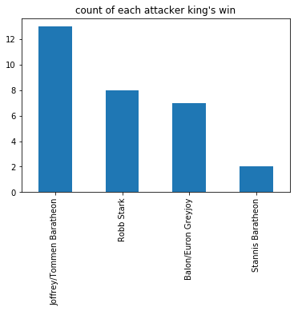

```python
# plot the count the number of each attacker king's win
df_attacker_win['attacker_king'].value_counts().plot(kind='bar',title="count of each attacker king's win");
```

```python
# Then, get all rows which the attacker outcome is loss, which means the defender wins
df_defender_win = df_1.query('attacker_outcome == "loss"')
# count the number of each defender king's win
df_defender_win['defender_king'].value_counts()
```

```
Joffrey/Tommen Baratheon    3
Mance Rayder                1
Robb Stark                  1
Name: defender_king, dtype: int64
```

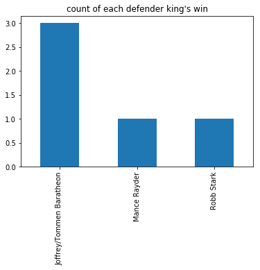

```python
# plot the count the number of each defender king's win
df_defender_win['defender_king'].value_counts().plot(kind='bar',title="count of each defender king's win");
```

```python
# plot the count the number of each defender king's win
df_defender_win['defender_king'].value_counts().plot(kind='bar',title="count of each defender king's win");
```

[output not shown]

```python
# Fianlly, I need to create a new dataframe which just include all data about each king's win regardless of attacker or defender
df_2 = df_attacker_win[['attacker_king','attacker_outcome']]
# rename the columns for combine
df_2 = df_2.rename(index=str, columns={'attacker_king':'win_king','attacker_outcome':'fight_outcome'})
df_2
```

|  | win_king | fight_outcome |
| --- | --- | --- |
| 0 | Joffrey/Tommen Baratheon | win |
| 1 | Joffrey/Tommen Baratheon | win |
| 2 | Joffrey/Tommen Baratheon | win |
| 4 | Robb Stark | win |
| 5 | Robb Stark | win |
| 6 | Joffrey/Tommen Baratheon | win |
| 7 | Balon/Euron Greyjoy | win |
| 8 | Balon/Euron Greyjoy | win |
| 9 | Balon/Euron Greyjoy | win |
| 10 | Robb Stark | win |
| 11 | Balon/Euron Greyjoy | win |
| 12 | Balon/Euron Greyjoy | win |
| 13 | Joffrey/Tommen Baratheon | win |
| 14 | Robb Stark | win |
| 15 | Stannis Baratheon | win |
| 17 | Robb Stark | win |
| 18 | Robb Stark | win |
| 20 | Robb Stark | win |
| 23 | Joffrey/Tommen Baratheon | win |
| 24 | Joffrey/Tommen Baratheon | win |
| 25 | Joffrey/Tommen Baratheon | win |
| 26 | Robb Stark | win |
| 28 | Joffrey/Tommen Baratheon | win |
| 30 | Stannis Baratheon | win |
| 31 | Balon/Euron Greyjoy | win |
| 32 | Balon/Euron Greyjoy | win |
| 33 | Joffrey/Tommen Baratheon | win |
| 34 | Joffrey/Tommen Baratheon | win |
| 35 | Joffrey/Tommen Baratheon | win |
| 36 | Joffrey/Tommen Baratheon | win |

```python
# rename the columns for combine
df_defender_win = df_defender_win.rename(index=str, columns={'defender_king':'win_king','attacker_outcome':'fight_outcome'})
df_3 = df_defender_win[['win_king', 'fight_outcome']]
df_3['fight_outcome'].replace(['loss'], ['win'], inplace=True)
df_3
```

|  | win_king | fight_outcome |
| --- | --- | --- |
| 3 | Joffrey/Tommen Baratheon | win |
| 16 | Robb Stark | win |
| 19 | Joffrey/Tommen Baratheon | win |
| 21 | Joffrey/Tommen Baratheon | win |
| 27 | Mance Rayder | win |

```python
# combine all win kings' data to one table
df_4 = pd.concat([df_2, df_3], axis=0, join='outer')
df_4
```

|  | win_king | fight_outcome |
| --- | --- | --- |
| 0 | Joffrey/Tommen Baratheon | win |
| 1 | Joffrey/Tommen Baratheon | win |
| 2 | Joffrey/Tommen Baratheon | win |
| 4 | Robb Stark | win |
| 5 | Robb Stark | win |
| 6 | Joffrey/Tommen Baratheon | win |
| 7 | Balon/Euron Greyjoy | win |
| 8 | Balon/Euron Greyjoy | win |
| 9 | Balon/Euron Greyjoy | win |
| 10 | Robb Stark | win |
| 11 | Balon/Euron Greyjoy | win |
| 12 | Balon/Euron Greyjoy | win |
| 13 | Joffrey/Tommen Baratheon | win |
| 14 | Robb Stark | win |
| 15 | Stannis Baratheon | win |
| 17 | Robb Stark | win |
| 18 | Robb Stark | win |
| 20 | Robb Stark | win |
| 23 | Joffrey/Tommen Baratheon | win |
| 24 | Joffrey/Tommen Baratheon | win |
| 25 | Joffrey/Tommen Baratheon | win |
| 26 | Robb Stark | win |
| 28 | Joffrey/Tommen Baratheon | win |
| 30 | Stannis Baratheon | win |
| 31 | Balon/Euron Greyjoy | win |
| 32 | Balon/Euron Greyjoy | win |
| 33 | Joffrey/Tommen Baratheon | win |
| 34 | Joffrey/Tommen Baratheon | win |
| 35 | Joffrey/Tommen Baratheon | win |
| 36 | Joffrey/Tommen Baratheon | win |
| 3 | Joffrey/Tommen Baratheon | win |
| 16 | Robb Stark | win |
| 19 | Joffrey/Tommen Baratheon | win |
| 21 | Joffrey/Tommen Baratheon | win |
| 27 | Mance Rayder | win |

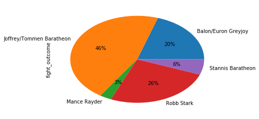

```python
# use pie chart to display the percentage of each king's win
df_4.groupby('win_king')['fight_outcome'].count().plot(kind = 'pie', autopct = '%.0f%%');
```

## Correlation Analysis

[output not shown]

```python
# first, I need to extract relative data
df_5 = df[['attacker_size', 'defender_size', 'attacker_outcome']]
df_5.head()
```

|  | attacker_size | defender_size | attacker_outcome |
| --- | --- | --- | --- |
| 0 | 15000.0 | 4000.0 | win |
| 1 | NaN | 120.0 | win |
| 2 | 15000.0 | 10000.0 | win |
| 3 | 18000.0 | 20000.0 | loss |
| 4 | 1875.0 | 6000.0 | win |

```python
# drop all data including NaN
df_5 = df_5.dropna(subset=['attacker_outcome', 'attacker_size', 'defender_size'])
df_5
```

|  | attacker_size | defender_size | attacker_outcome |
| --- | --- | --- | --- |
| 0 | 15000.0 | 4000.0 | win |
| 2 | 15000.0 | 10000.0 | win |
| 3 | 18000.0 | 20000.0 | loss |
| 4 | 1875.0 | 6000.0 | win |
| 5 | 6000.0 | 12625.0 | win |
| 10 | 244.0 | 900.0 | win |
| 13 | 618.0 | 2000.0 | win |
| 14 | 6000.0 | 10000.0 | win |
| 15 | 5000.0 | 20000.0 | win |
| 16 | 20000.0 | 10000.0 | loss |
| 17 | 100.0 | 100.0 | win |
| 19 | 21000.0 | 7250.0 | loss |
| 25 | 3500.0 | 3500.0 | win |
| 27 | 100000.0 | 1240.0 | loss |
| 30 | 4500.0 | 200.0 | win |

```python
# calculate the difference
df_5['differece_size'] = df_5['attacker_size'] - df_5['defender_size']
df_5.head()
```

|  | attacker_size | defender_size | attacker_outcome | differece_size |
| --- | --- | --- | --- | --- |
| 0 | 15000.0 | 4000.0 | win | 11000.0 |
| 2 | 15000.0 | 10000.0 | win | 5000.0 |
| 3 | 18000.0 | 20000.0 | loss | -2000.0 |
| 4 | 1875.0 | 6000.0 | win | -4125.0 |
| 5 | 6000.0 | 12625.0 | win | -6625.0 |

```python
# covert the outcome from string to int
df_5[['attacker_loss', 'attacker_win']] = pd.get_dummies(df_5['attacker_outcome'])
df_5 = df_5.drop('attacker_loss', axis=1)
df_5
```

|  | attacker_size | defender_size | attacker_outcome | differece_size | attacker_win |
| --- | --- | --- | --- | --- | --- |
| 0 | 15000.0 | 4000.0 | win | 11000.0 | 1 |
| 2 | 15000.0 | 10000.0 | win | 5000.0 | 1 |
| 3 | 18000.0 | 20000.0 | loss | -2000.0 | 0 |
| 4 | 1875.0 | 6000.0 | win | -4125.0 | 1 |
| 5 | 6000.0 | 12625.0 | win | -6625.0 | 1 |
| 10 | 244.0 | 900.0 | win | -656.0 | 1 |
| 13 | 618.0 | 2000.0 | win | -1382.0 | 1 |
| 14 | 6000.0 | 10000.0 | win | -4000.0 | 1 |
| 15 | 5000.0 | 20000.0 | win | -15000.0 | 1 |
| 16 | 20000.0 | 10000.0 | loss | 10000.0 | 0 |
| 17 | 100.0 | 100.0 | win | 0.0 | 1 |
| 19 | 21000.0 | 7250.0 | loss | 13750.0 | 0 |
| 25 | 3500.0 | 3500.0 | win | 0.0 | 1 |
| 27 | 100000.0 | 1240.0 | loss | 98760.0 | 0 |
| 30 | 4500.0 | 200.0 | win | 4300.0 | 1 |

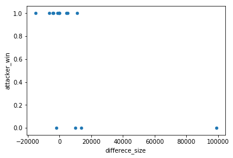

```python
# using scatter to display the correlation
df_5.plot(x='differece_size', y='attacker_win', kind='scatter');
```

## From the scatter, it seems like the difference between tha attacker and defender size and the outcome of fight have no clear linear correlation. But I need to use linear regression to have a try.

```python
# reset the index
df_5.reset_index(drop=True, inplace=True)
```

```python
import statsmodels.api as sm

df_5['intercept'] = 1
los_mod = sm.OLS(df_5['attacker_win'], df_5[['intercept', 'differece_size']])
results = los_mod.fit()
results.summary()
```

OLS Regression Results

| Dep. Variable: | attacker_win | R-squared: | 0.293 |
| --- | --- | --- | --- |
| Model: | OLS | Adj. R-squared: | 0.239 |
| Method: | Least Squares | F-statistic: | 5.391 |
| Date: | Sat, 21 Jul 2018 | Prob (F-statistic): | 0.0371 |
| Time: | 11:31:36 | Log-Likelihood: | -6.4427 |
| No. Observations: | 15 | AIC: | 16.89 |
| Df Residuals: | 13 | BIC: | 18.30 |
| Df Model: | 1 |  |  |
| Covariance Type: | nonrobust |  |  |

|  | coef | std err | t | P>\|t\| | [0.025 | 0.975] |
| --- | --- | --- | --- | --- | --- | --- |
| intercept | 0.8017 | 0.107 | 7.476 | 0.000 | 0.570 | 1.033 |
| differece_size | -9.404e-06 | 4.05e-06 | -2.322 | 0.037 | -1.82e-05 | -6.54e-07 |

| Omnibus: | 7.667 | Durbin-Watson: | 2.438 |
| --- | --- | --- | --- |
| Prob(Omnibus): | 0.022 | Jarque-Bera (JB): | 5.248 |
| Skew: | -1.444 | Prob(JB): | 0.0725 |
| Kurtosis: | 3.249 | Cond. No. | 2.75e+04 |

When performing exploratory data analysis, please make sure you record your key steps and reasoning processes during the data analysis. You can insert code cells and markdown cells to organize your report.

## Draw conclusions

**Question**: Can the aforesaid analysis answer the question you have set? What conclusions can you draw from the analysis?

**Answer**: From the analysis, I get the answer of the question I have set, and from the data shows, I can know that between 298 to 300, 'Joffrey/Tommen Baratheon' is the king which wins the most victories, and about half of the battles are won by this king. Also, he wins the most victories as defender.

## Further Reflections

**Question**: Is your logic rigorous during your analysis and summary? Is there any space for further improvement? You can think about these questions from the following perspectives:

1. Is the dataset integral? Does it contain all data you want to analyze? ### In fact, the data analysis is not comprehensive because the number of data is quite small, but it includes relative data which I want to use for analysis.
2. May your operation (for example, delete/fill missing values) influence your conclusion during data process? ### In the process of analyzing, I droped two rows which cannot insure the attacker and defender, and it would not influence the result as these two rows have no relative information about the question. But I remained one row which include the attacker and the outcome of the fight because these data will affact the result.
3. Are there any other variables (which are not contained in the dataset) to help your analysis? ### The number of people before the fight, and the number of people after the fight.
4. Have you mixed correlation and causality when drawing a conclusion? ### No, it just has correlation.

Congratulate you on finishing this project! This is only a sample of the data analysis process: Generate questions, analyze data, explore data and draw a conclusion. When proceeding with a manometer degree of data analysis (advanced), you will learn more advanced data analysis methods and technologies. If you are interested, we encourage you to proceed with subsequent courses and master more advanced data analysis skills!

> **Tip**: If we want to share the results of our analysis with others, we aren't limited to giving them a copy of the jupyter Notebook (.ipynb) file. We can also export the Notebook output in a form that can be opened even for those without Python installed. From the **File** menu in the upper left, go to the **Download as** submenu. You can then choose a different format that can be viewed more generally, such as HTML (.html) or PDF (.pdf). You may need additional packages or software to perform these exports.